# Modelo de Aiyagari - Mercados Incompletos

## Unexpected Aggregate Shocks and Transition Dynamics

- Queremos estudar a trajetória de transição após um choque inesperado do estado estacionário inicial para o novo estado estacionário.
- Suponha um choque permanente na alíquota de taxação sobre o capital
  - a arrecadação $T$ é devolvida *lump sum* para os indivíduos
  - inicialmente alíquota de taxação $\tau = 0 \implies$ arrecadação $T = 0$
  - Após o choque $\tau > 0$: aumento da taxação

#### Definição de Funções

```python
import numpy as np
import matplotlib.pyplot as plt

###########################################################################
# Funções
###########################################################################
def util(x):
    # return ( x**(1-sigma) -1)/(1-sigma)
    return ( x**(1-sigma) -1)/(1-sigma)
###########################################################################
def define_parameters_and_objects():
    global beta, rho, sigma, r, w, delta, alpha, pi, y_grid,\
            a_grid, n_y, n_a, V, iG, Tr, tau, L

    sigma, r = 2, 0.05
    beta = .9
    rho = beta**(-1) - 1
    delta, alpha = 0.04, 0.3
    Tr, tau = 0, 0
#    k = (alpha/r)**(1/(1-alpha))
#    w = (1-alpha)*(k**alpha)

    pi = np.array([
                    [2/3, 1/3],
                    [1/3, 2/3]
                    ])
    y_min, y_max, n_y = 1e-2, 1, len(pi)
    y_grid = np.linspace(y_min, y_max, n_y)

    barA, a_max, n_a = 0, 20, 50
    a_grid = np.linspace(-barA, a_max, n_a)

    V = np.zeros( (n_y, n_a) )
    iG = np.zeros( (n_y, n_a) , dtype=np.int64 )

    L = compute_Ey()
###########################################################################
def compute_Ey():
    barPI = compute_barPI()
    Ey = 0
    for i_y, y in enumerate(y_grid):
        mea = barPI[i_y]
        lab = y
        Ey += lab*mea
    return Ey
###########################################################################
def compute_barPI():
    barPI = np.ones( n_y )/n_y
    norm_pi, tol_pi = 1, 1e-12
    while norm_pi>tol_pi:
        T_barPI = np.dot(barPI, pi)
        norm_pi = max(abs(T_barPI-barPI))
        barPI = T_barPI/sum(T_barPI)
    return barPI
###########################################################################
def build_objective(V, r):
    global w, Tr, tau
    k = compute_k(r)
    w = compute_w(k)
    F_OBJ = np.zeros( (n_y, n_a, n_a) )
    for i_y in range(n_y):
        y = y_grid[i_y]
    #for i_y, y in enumerate(y_grid):
        for i_a, a in enumerate(a_grid):
            for i_aa, aa in enumerate(a_grid):
                c = w*y + (1+(1-tau)*r)*a - aa + Tr
                if c<=0:
                    F_OBJ[i_y, i_a, i_aa] = -np.inf
                else:
                    F_OBJ[i_y, i_a, i_aa] = util(c) + beta*(  np.dot(pi[i_y,:],V[:, i_aa]) )
    return F_OBJ
###########################################################################
def compute_k(r):
    return (alpha/(r+delta))**(1/(1-alpha))
###########################################################################
def compute_w(k):
    return (1-alpha)*(k**alpha)
###########################################################################
def compute_r(K):
    global L
    return alpha*((K/L)**(alpha-1)) - delta
###########################################################################
def compute_TV_and_TG(F_OBJ):
    TV = np.zeros( (n_y, n_a) )
    T_iG = np.zeros( (n_y, n_a) , dtype=np.int64 )
    for i_y in range(n_y):
        for i_a in range(n_a):
            TV[i_y, i_a] = np.max(F_OBJ[i_y, i_a, :])
            T_iG[i_y, i_a] = np.argmax(F_OBJ[i_y, i_a, :])
    return TV, T_iG
###########################################################################
def compute_V_and_G():
    global V, iG, r
    norm, tol = 1, 1e-2
    while norm>tol:
        F_OBJ = build_objective(V, r)
        TV, T_iG = compute_TV_and_TG(F_OBJ)
        norm = np.max(abs(TV-V))
        V = np.copy(TV)
        iG = np.copy(T_iG)
#        print('norm =',norm)
    return V, iG
###########################################################################
def compute_Q(iG):
    # States values
    # [ (y_0, a_0), (y_0, a_1), (y_0, a_2), (y_0, a_3), (y_0, a_4) ,
    #   (y_1, a_0), (y_1, a_1), (y_1, a_2), (y_1, a_3), (y_1, a_4) ]
    Q = np.zeros( (n_y*n_a, n_y*n_a) )

    for i_y in range(n_y):
        for i_a in range(n_a):
            c_state = i_y*n_a+i_a
            for i_yy in range(n_y):
                for i_aa in range(n_a):
                    n_state = i_yy*n_a+i_aa
                    if iG[i_y,i_a] == i_aa:
                        Q[c_state, n_state] += pi[i_y,i_yy]
    return Q
###########################################################################
def compute_bar_phi(Q):
    bar_phi = np.ones( n_y*n_a )/(n_y*n_a)
    norm_M, tol_M = 1, 1e-12
    while norm_M>tol_M:
        Tbar_phi = np.dot(bar_phi, Q)
        norm_M = max(abs(Tbar_phi-bar_phi))
        bar_phi = Tbar_phi/sum(Tbar_phi)
    return bar_phi
###########################################################################
def compute_Ea(bar_phi):
    Ea = 0
    for i_y in range(n_y):
        for i_a in range(n_a):
            c_state = i_y*n_a+i_a
            mea = bar_phi[c_state]
            s_index = iG[i_y,i_a]
            sav = a_grid[ s_index ]
            Ea += sav*mea
    return Ea
###########################################################################
def compute_d(bar_phi):
    k = compute_k(r)
    L = compute_Ey()
    K = k*L
    Ea = compute_Ea(bar_phi)
    d = K - Ea
#    print('(K,Ea,d) = (',K,Ea,d,')')
    return d
###########################################################################
def compute_equilibrium():
    global r, w, V, iG, Q, bar_phi, Tr, tau, L
    r_L, r_H = -delta, rho
    norm_r, tol_r = 1, 1e-8
    while norm_r>tol_r:
        r = (r_L+r_H)/2
        k = compute_k(r)
        Tr = tau*r*k*L
        V, iG = compute_V_and_G()
        Q = compute_Q(iG)
    #    print(Q)
        bar_phi = compute_bar_phi(Q)
    #    print(bar_phi)
        d = compute_d(bar_phi)
        if d>0:
            r_L = r
        elif d<0:
            r_H = r
        norm_r = abs(r_H-r_L)
        # norm_r = max(abs(r_H-r_L),abs(d))
        print('[d,r_L,r_H,norm]=[{:9.6f},{:9.6f},{:9.6f},{:9.6f}]'.format(d,r_L,r_H,norm_r))
```

### Computação da Trajetória de Transição

##### Passo 1

Compute o equilíbrio estacionário $\Phi_0, v_0, c_0, a_1, r_0, w_0, K_0$ associado com $\tau_0 = 0$.

```python
## Inicializando o código
define_parameters_and_objects()

## Passo 1.
print('\nCalculando o SS inicial')
tau = 0
compute_equilibrium()
phi_0 = np.copy(bar_phi)
V_0 = np.copy(V)
iG_0 = np.copy(iG)
r_0 = np.copy(r)
w_0 = np.copy(w)
Tr_0 = np.copy(Tr)
K_0 = compute_Ea(phi_0)
```

```
Calculando o SS inicial
[d,r_L,r_H,norm]=[-1.136091,-0.040000, 0.035556, 0.075556]
[d,r_L,r_H,norm]=[ 4.899493,-0.002222, 0.035556, 0.037778]
[d,r_L,r_H,norm]=[ 0.719504, 0.016667, 0.035556, 0.018889]
[d,r_L,r_H,norm]=[-0.169993, 0.016667, 0.026111, 0.009444]
[d,r_L,r_H,norm]=[ 0.134641, 0.021389, 0.026111, 0.004722]
[d,r_L,r_H,norm]=[-0.121026, 0.021389, 0.023750, 0.002361]
[d,r_L,r_H,norm]=[ 0.003879, 0.022569, 0.023750, 0.001181]
[d,r_L,r_H,norm]=[-0.059282, 0.022569, 0.023160, 0.000590]
[d,r_L,r_H,norm]=[-0.027882, 0.022569, 0.022865, 0.000295]
[d,r_L,r_H,norm]=[-0.012047, 0.022569, 0.022717, 0.000148]
[d,r_L,r_H,norm]=[-0.004095, 0.022569, 0.022643, 0.000074]
[d,r_L,r_H,norm]=[-0.000111, 0.022569, 0.022606, 0.000037]
[d,r_L,r_H,norm]=[ 0.001883, 0.022588, 0.022606, 0.000018]
[d,r_L,r_H,norm]=[ 0.000886, 0.022597, 0.022606, 0.000009]
[d,r_L,r_H,norm]=[ 0.000387, 0.022602, 0.022606, 0.000005]
[d,r_L,r_H,norm]=[ 0.000138, 0.022604, 0.022606, 0.000002]
[d,r_L,r_H,norm]=[ 0.000014, 0.022605, 0.022606, 0.000001]
[d,r_L,r_H,norm]=[-0.000049, 0.022605, 0.022606, 0.000001]
[d,r_L,r_H,norm]=[-0.000018, 0.022605, 0.022605, 0.000000]
[d,r_L,r_H,norm]=[-0.000002, 0.022605, 0.022605, 0.000000]
[d,r_L,r_H,norm]=[ 0.000006, 0.022605, 0.022605, 0.000000]
[d,r_L,r_H,norm]=[ 0.000002, 0.022605, 0.022605, 0.000000]
[d,r_L,r_H,norm]=[-0.000000, 0.022605, 0.022605, 0.000000]
[d,r_L,r_H,norm]=[ 0.000001, 0.022605, 0.022605, 0.000000]
```

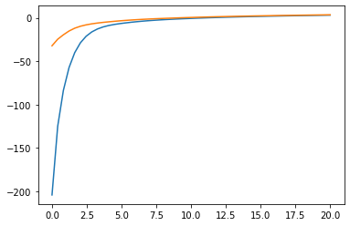

```python
# Gráfico - Funções Valor
plt.plot(a_grid, V_0[0,:])
plt.plot(a_grid, V_0[1,:])
plt.show()
```

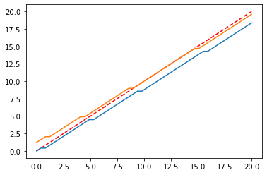

```python
# Gráfico - Funções Políticas
G_0 = a_grid[iG_0]
plt.plot(a_grid, a_grid, "r--")
plt.plot(a_grid,G_0[0,:])
plt.plot(a_grid,G_0[1,:])
plt.show()
```

##### Passo 2

Compute o equilíbrio estacionário $\Phi_\infty, v_\infty, c_\infty, a_\infty, r_\infty, w_\infty, K_\infty$ associado com $\tau_\infty = \tau$.

```python
## Passo 2.
print('\nCalculando o SS final')
tau = 0.05
compute_equilibrium()
Phi_inf = np.copy(bar_phi)
V_inf = np.copy(V)
iG_inf = np.copy(iG)
r_inf = np.copy(r)
w_inf = np.copy(w)
Tr_inf = np.copy(Tr)
K_inf = compute_Ea(Phi_inf)
```

```
Calculando o SS final
[d,r_L,r_H,norm]=[-0.898999,-0.040000, 0.035556, 0.075556]
[d,r_L,r_H,norm]=[ 4.899493,-0.002222, 0.035556, 0.037778]
[d,r_L,r_H,norm]=[ 0.941338, 0.016667, 0.035556, 0.018889]
[d,r_L,r_H,norm]=[-0.141356, 0.016667, 0.026111, 0.009444]
[d,r_L,r_H,norm]=[ 0.513347, 0.021389, 0.026111, 0.004722]
[d,r_L,r_H,norm]=[ 0.087362, 0.023750, 0.026111, 0.002361]
[d,r_L,r_H,norm]=[-0.032049, 0.023750, 0.024931, 0.001181]
[d,r_L,r_H,norm]=[ 0.026991, 0.024340, 0.024931, 0.000590]
[d,r_L,r_H,norm]=[-0.002693, 0.024340, 0.024635, 0.000295]
[d,r_L,r_H,norm]=[ 0.012108, 0.024488, 0.024635, 0.000148]
[d,r_L,r_H,norm]=[ 0.004698, 0.024562, 0.024635, 0.000074]
[d,r_L,r_H,norm]=[ 0.001000, 0.024599, 0.024635, 0.000037]
[d,r_L,r_H,norm]=[-0.000847, 0.024599, 0.024617, 0.000018]
[d,r_L,r_H,norm]=[ 0.000076, 0.024608, 0.024617, 0.000009]
[d,r_L,r_H,norm]=[-0.000385, 0.024608, 0.024612, 0.000005]
[d,r_L,r_H,norm]=[-0.000154, 0.024608, 0.024610, 0.000002]
[d,r_L,r_H,norm]=[-0.000039, 0.024608, 0.024609, 0.000001]
[d,r_L,r_H,norm]=[ 0.000019, 0.024608, 0.024609, 0.000001]
[d,r_L,r_H,norm]=[-0.000010, 0.024608, 0.024609, 0.000000]
[d,r_L,r_H,norm]=[ 0.000004, 0.024608, 0.024609, 0.000000]
[d,r_L,r_H,norm]=[-0.000003, 0.024608, 0.024609, 0.000000]
[d,r_L,r_H,norm]=[ 0.000001, 0.024609, 0.024609, 0.000000]
[d,r_L,r_H,norm]=[-0.000001, 0.024609, 0.024609, 0.000000]
[d,r_L,r_H,norm]=[-0.000000, 0.024609, 0.024609, 0.000000]
```

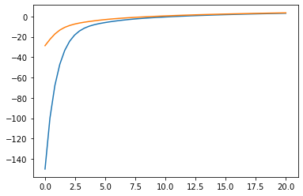

```python
# Gráfico - Funções Valor
plt.plot(a_grid,V_inf[0,:])
plt.plot(a_grid,V_inf[1,:])
plt.show()
```

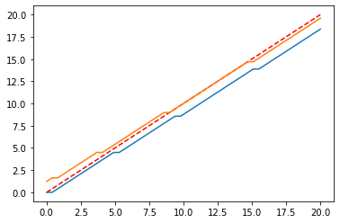

```python
# Gráfico - Funções Políticas
G_inf = a_grid[iG_inf]
plt.plot(a_grid, a_grid, "r--")
plt.plot(a_grid,G_inf[0,:])
plt.plot(a_grid,G_inf[1,:])
plt.show()
```

##### Passo 3

Fixe $N$. Assuma que $$ \Phi_N, v_N, c_N, a_N, r_N, w_N, K_N = \Phi_\infty, v_\infty, c_\infty, a_\infty, r_\infty, w_\infty, K_\infty $$

##### Passo 4

Chute uma sequência de estoques de capital $\{\hat{K}_t\}^{N-1}_{t=1}$

- Note que, como o estoque de capital no período $t=1$ é determinado pelas decisões no tempo $0$, temos que $\hat{K}_1 = K_0$
- Também, note que $L_t = L_0 = \bar{L}$ é fixo.

##### Passo 4.5

Então, com os chutes no estoque de capital, obtemos $\{\hat{r}_t, \hat{w}_t, \hat{T}_t\}^{N-1}_{t=1}$ determinados por \begin{align*} \hat{w}_t &= F_L(\hat{K}_t, \bar{L}) \\ \hat{r}_t &= F_k(\hat{K}_t, \bar{L}) - \delta \\ \hat{T}_t &= \tau_t \hat{r}_t \hat{K}_t \end{align*}

##### Passo 5

Como conhecemos $v_N(a, y)$ e $\{\hat{r}_t, \hat{w}_t, \hat{T}_t\}^{N-1}_{t=1}$ podemos solucionar para $\{\hat{v}_t, \hat{c}_t, \hat{a}_{t+1}\}^{N-1}_{t=1}$ retroativamente. \begin{align*} v_{t}(a, y) &= \max_{c\ge0,\ a'\ge0}\left\{ U(c) + \beta \sum_{y'\in Y}{\pi(y' | y) v_{t+1}(a', y')} \right\} \\ &\qquad \text{s.t. }\ c + a' = w_t y + (1 + (1 - \tau_t)r_t) a + T_t \end{align*}

##### Passo 6

Com as funções políticas $\{\hat{a}_{t+1}\}$, podemos definir as leis de transição $\{\Gamma_t\}^{N-1}_{t=1}$. Mas como sabemos que $\Phi_0 = \Phi_1$ do equilíbrio estacionário inicial, podemos iterar as distribuições para frente $$ \hat{\Phi}_{t+1} = \Gamma_t(\hat{\Phi}_t) $$ para $t = 1, ..., N-1$.

##### Passo 7

Com $\{\hat{\Phi}_t\}^N_{t=1}$, podemos computar $$ \hat{A}_t = \int{a\ d\hat{\Phi}_t} $$ para $t = 1, ..., N$.

##### Passo 8

Verifique se $$ \max_{1\le t \le N}\left| \hat{A}_t - \hat{K}_t \right| < \varepsilon $$ Se sim, vá para passo 9. Caso contrário, ajuste chutes para $\{\hat{K}_t\}^{N-1}_{t=1}$ no passo 4.

##### Passo 9

Verifique se $\left\| \hat{\Phi}_N - \Phi_N \right\| < \varepsilon$.

- Se sim, $N$ é suficientemente grande, a transição converge suavemente no novo estado estacionário e guardamos $\{\hat{v}_t, \hat{a}_{t+1}, \hat{c}_t, \hat{\Phi}_t, \hat{r}_t, \hat{w}_t, \hat{K}_t\}$.
- Se não, vá para o passo 3 e aumente $N$.

```
N = 20
```

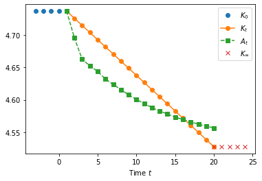

```
Norma da trajetória de Capital: 0.051960418104094686
```

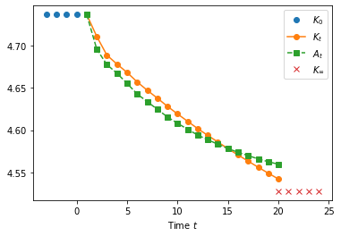

```
Norma da trajetória de Capital: 0.017373775374683653
```

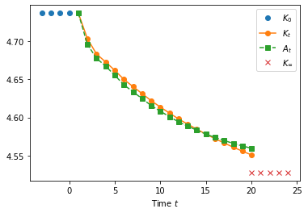

```
Norma da trajetória de Capital: 0.00868688768734227
```

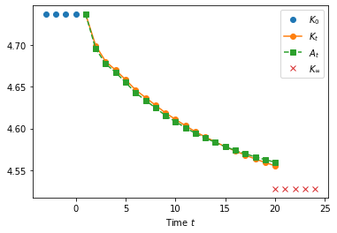

```
Norma da trajetória de Capital: 0.004343443843670691
```

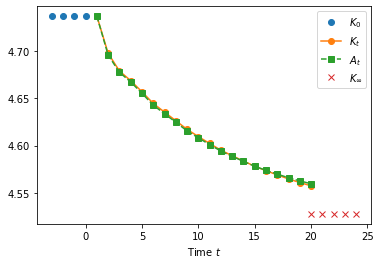

```
Norma da trajetória de Capital: 0.0021717219218357897
```

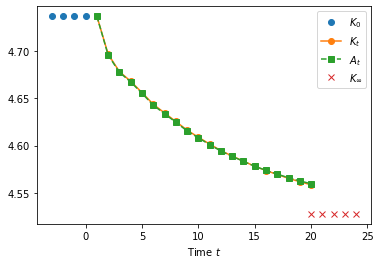

```
Norma da trajetória de Capital: 0.0010858609609174508
```

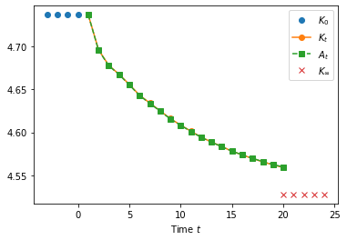

```
Norma da trajetória de Capital: 0.0005429304804591695
Norma da distribuição final: 0.0008203892541332504 20

======================================================================

N = 40
```

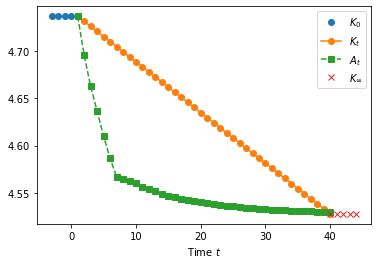

```
Norma da trajetória de Capital: 0.13691831067710059
```

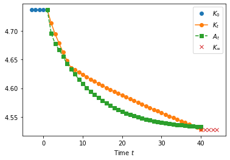

```
Norma da trajetória de Capital: 0.02807872344814122
```

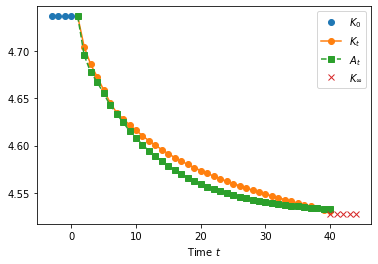

```
Norma da trajetória de Capital: 0.01403936172407061
```

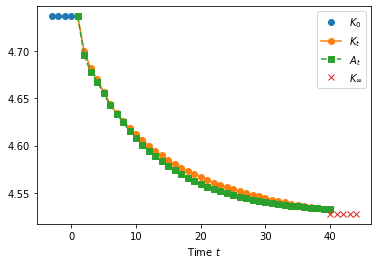

```
Norma da trajetória de Capital: 0.0070196808620348605
```

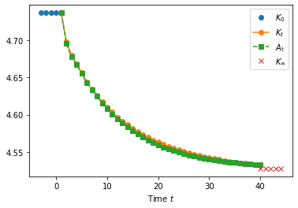

```
Norma da trajetória de Capital: 0.0035098404310174303
```

[18 more figures not shown]

```
Norma da trajetória de Capital: 0.0007199175694490023
Norma da distribuição final: 2.7562228107989167e-06 80

======================================================================
```

```python
## Passo 3.
N = 0
norm_Phi, tol_Phi = 1, 1e-5
while (norm_Phi>tol_Phi):
    N += 20
    print("N =", N)

    ## Passo 4.
    K_path = np.ones(N)
    for t in range(N):
        K_path[t] = (K_inf*t + K_0*(N-1-t)) / (N-1)  # trajetória linear entre os capitais
    # print(K_path)
    # fig, ax = plt.subplots()
    # ax.plot(range(N), K_path,'-o')

    norm_K_path, tol_K_path = 1, 1e-3

    ## Passo 4.
    while (norm_K_path>tol_K_path):
        r_path, w_path, Tr_path = np.ones(N), np.ones(N), np.ones(N)
        for t in range(N):
            r_path[t] = compute_r( K_path[t] )
            w_path[t] = compute_w( K_path[t] / L )
            Tr_path[t] = tau*r_path[t]*K_path[t]

        # fig, ax = plt.subplots(2,2, figsize=(12,9))
        # t_grid = [t+1 for t in range(N)]
        # ax[0,0].plot(t_grid,K_path,'o-')
        # ax[0,1].plot(t_grid,r_path,'o-')
        # ax[1,0].plot(t_grid,w_path,'o-')
        # ax[1,1].plot(t_grid,Tr_path,'o-')
        # plt.show()


        ## Passo 5.
        V_path = np.zeros( (n_y, n_a, N) )
        V_path[:,:,N-1] = V_inf
        iG_path = np.zeros( (n_y, n_a, N), dtype=np.int64 )
        iG_path[:,:,N-1] = iG_inf
        # plt.plot(a_grid, V_path[0,:,N-1])

        for t in range(N,1,-1):
            # print(t)
            V = V_path[:,:,t-1]
            r = r_path[t-2]
            w = w_path[t-2]
            Tr = Tr_path[t-2]

            F_OBJ = build_objective(V, r)
            V, iG = compute_TV_and_TG(F_OBJ)

            V_path[:,:,t-2] = V
            iG_path[:,:,t-2] = iG
            # plt.plot(a_grid, V_path[0,:,t-2])

        ## Passo 6.
        Gamma_path = np.zeros( (n_y*n_a, n_y*n_a, N) )
        for t in range(N):
            iG = iG_path[:,:,t]
            Gamma_path[:,:,t] = compute_Q(iG)

        phi_path = np.zeros( (N, n_y*n_a) )
        phi_path[0,:] = phi_0
        for t in range(1,N):
            # print(t)
            Phi_t = phi_path[t-1,:]
            Gamma_t = Gamma_path[:,:,t-1]
            phi_path[t,:] = np.dot(Phi_t, Gamma_t)

        ## Passo 7.
        A_path = np.zeros( N )
        #A_path[t] = compute_Ea()

        for t in range(N):
            Ea_t = 0
            for i_y in range(n_y):
                for i_a in range(n_a):
                    c_state = i_y*n_a+i_a
                    Phi_t = phi_path[t,:]
                    mea = Phi_t[c_state]
                    # iG_t = iG_path[:,:,t]
                    # s_index = iG_t[i_y,i_a]
                    a = a_grid[ i_a ]
                    Ea_t += a*mea
            A_path[t] = Ea_t

        # print('\nTrajetória de Capital:\n',K_path)
        # print('\nTrajetória de Poupança:\n',A_path)
        fig, ax = plt.subplots()
        t_grid = [t+1 for t in range(N)]
        ax.plot([1-i for i in range(5)], [K_0 for i in range(5)],'o',label='$K_0$')
        ax.plot(t_grid, K_path,'-o',label='$K_t$')
        ax.plot(t_grid, A_path,'--s',label='$A_t$')
        ax.set_xlabel('Time $t$')
        ax.plot([N+i for i in range(5)], [K_inf for i in range(5)],'x',label='$K_\infty$')
        plt.legend(loc='best')
        plt.show()

        ## Passo 8.
        norm_K_path = np.max([abs(A_path[ii]-K_path[ii]) for ii in range(N)])
        # norm_K_path = np.max([abs(A_path[ii]-K_path[ii]) for ii in range(N-1)])
        print('Norma da trajetória de Capital:',norm_K_path)
        mu = .5
        for ii in range(1,N):
        # for ii in range(1,N-1):
            # print(ii)
            K_path[ii] = (mu*K_path[ii]+(1-mu)*A_path[ii])

    ## Passo 9.
    norm_Phi = np.max(abs(phi_path[N-1,:]-Phi_inf))
    print('Norma da distribuição final:',norm_Phi,N,'\n')
    print('======================================================================\n')
```

### Análise de Welfare

```python
###############################################################################
## Welfare analysis
eta = 1/((1-beta)*(1-sigma))
```

#### Incluindo a transição

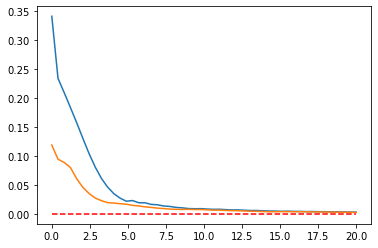

```python
###############################################################################
# Welfare impact distribution: taking the transition into account
g = np.zeros( (n_y,n_a) )
V_1 = V_path[:,:,0]
for i_y in range(n_y):
    for i_a in range(n_a):
        g[i_y, i_a] = ( (V_1[i_y,i_a]+eta)/(V_0[i_y,i_a]+eta) )**(1/(1-sigma)) - 1

fig, ax = plt.subplots()
for i_y in range(n_y):
    ax.plot(a_grid, g[i_y, :])
ax.plot(a_grid, [0]*n_a, 'r--')
plt.show()
```

#### Comparando estados estacionários

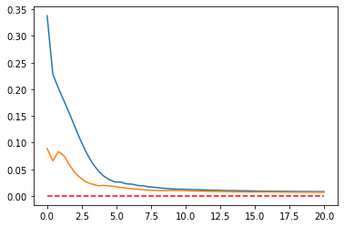

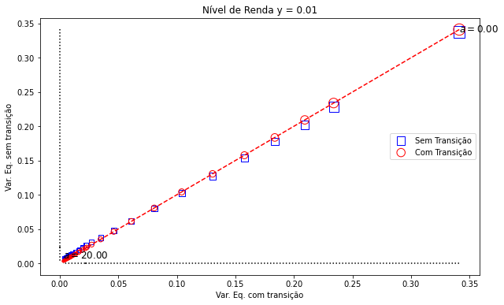

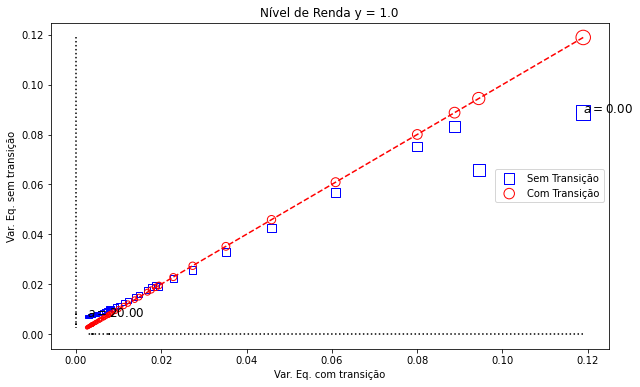

```python
###############################################################################
# Welfare impact distribution: comparing steady states
gSS = np.zeros( (n_y,n_a) )
for i_y in range(n_y):
    for i_a in range(n_a):
        gSS[i_y, i_a] = ( (V_inf[i_y,i_a]+eta)/(V_0[i_y,i_a]+eta) )**(1/(1-sigma)) - 1

fig, ax = plt.subplots()
for i_y in range(n_y):
    ax.plot(a_grid, gSS[i_y, :])
ax.plot(a_grid, [0]*n_a, 'r--')
plt.show()

a_max = a_grid[-1]
for i_y, y in enumerate(y_grid):
    fig, ax = plt.subplots(figsize=(10,6))
    # ax.plot(a_grid, g[i_y, :])
    full = g[i_y, :]
    ax.plot(full, full, 'r--')
    # ax.scatter(full,full)
    ax.plot(full, [0]*n_a, 'k:')
    ax.plot([0]*n_a, full, 'k:')
    plt.title(f'Nível de Renda y = {y}')
    # ax.plot(g[i_y, :], gSS[i_y, :],'o')
    size = [10*(1+a_max)/(1+a) for a in a_grid]

    ax.scatter(full, gSS[i_y, :], s=size, facecolors='none', edgecolors='b',label='Sem Transição',marker='s')
    ax.scatter(full, full, s=size, facecolors='none', edgecolors='r',label='Com Transição')

    ax.set_xlabel('Var. Eq. com transição')
    ax.set_ylabel('Var. Eq. sem transição')

    # TESTE
    # for i in zip([2,6,7], [3,1,5]):
    #     print(i)
    # it = 0
    x, y = g[i_y, 0], gSS[i_y, 0]
    ax.annotate(f'$a = {a_grid[0]:.2f}$', xy=(x,y), size=12)
    x, y = g[i_y, -1], gSS[i_y, -1]
    ax.annotate(f'$a = {a_grid[-1]:.2f}$', xy=(x,y), size=12)
    plt.legend()
    plt.show()
```

#### Impacto Médio

```python
###############################################################################
# Average welfare impact
E_g = np.zeros( (n_y,n_a) )
EV_inf = 0
EV_0 = 0
for i_y in range(n_y):
    for i_a in range(n_a):
        linear_index = i_y*n_a+i_a
        EV_inf += V_inf[i_y, i_a]*Phi_inf[linear_index]
        EV_0 +=  V_0[i_y, i_a] *phi_0[linear_index]
E_g = ( (EV_inf+eta)/(EV_0+eta) )**(1/(1-sigma)) - 1

E_g

# compute_Ea(Phi_inf)-compute_Ea(phi_path[N-1,:])
# max(abs(Phi_inf-phi_path[N-1,:]))
```

```
-0.013290088280646817
```